# A potato Analysis

2024-03-18

#### *Introduction*

**Goal**: You should model the **Flavor score** as a function of the explanatory factors (i.e. leave out Texture score and Moistness score)

**Dataset**: potato.dat

**Source**: A. Mackey and J. Stockman (1958). “Cooking Quality of Oregon-Grown Russet Potatoes”, American Potato Journal, Vol.35, pp395-407

**Description**: Texture, Flavor, and Moistness Scores for potatoes of 2 sizes, from two areas, two holding temps, 4 holding periods, and 5 cooking methods. Each score is an average of 20 scores (5 judges x 4 replications).

Variables/Columns

Growing Area 8 /* 1=Southern OR, 2=Central OR */ Two week holding temp 16 /* 1=75F 2=40F */ Size of Potato 24 /* 1=Large, 2=Medium */ Storage Period 32 /* 1=0 months, 2=2 mths 3=4mths, 4=6mths */ Cooking method 40 /* 1=Boil, 2=Steam, 3=Mash, 4=Bake@350, 5=Bake@450 */ Texture score 46-48 Flavor score 54-56 Moistness score 62-64

#### *Importing the dataset from URL*

```r
url <- "http://users.stat.ufl.edu/~winner/data/potato.dat"
potato_data <- read.table(url, header = FALSE)

colnames(potato_data) <- c("Growing_Area", "Temperature", "Size", "Storage_period", "Cooking_Method", "Texture", "Flavor", "Moistness")

potato_data <- potato_data[, !colnames(potato_data) %in% c("Texture", "Moistness")]


potato_data
```

```
##     Growing_Area Temperature Size Storage_period Cooking_Method Flavor
## 1              1           1    1              1              1    3.2
## 2              1           1    1              1              2    2.5
## 3              1           1    1              1              3    2.8
## 4              1           1    1              1              4    2.9
## 5              1           1    1              1              5    2.8
## 6              1           1    1              2              1    3.0
## 7              1           1    1              2              2    3.1
## 8              1           1    1              2              3    3.0
## 9              1           1    1              2              4    3.2
## 10             1           1    1              2              5    2.8
## 11             1           1    1              3              1    2.6
## 12             1           1    1              3              2    2.8
## 13             1           1    1              3              3    2.6
## 14             1           1    1              3              4    3.2
```

[output cut: 146 more lines]

#### *Pre analysis to choose the regression model*

```r
#overall mean
overall_mean_flavor <- mean(potato_data$Flavor)
cat("Mean flavor score overall:", overall_mean_flavor, "\n")
```

```
## Mean flavor score overall: 2.91125
```

```r
#Compute the mean flavor score for each different area
mean_flavor_area <- tapply(potato_data$Flavor, potato_data$Growing_Area, mean)
cat("Mean flavor score for each area:\n")
```

```
## Mean flavor score for each area:
```

```r
print(mean_flavor_area)
```

```
##       1       2
## 2.85375 2.96875
```

```r
# 3. Compute the mean flavor score for each temperature
mean_flavor_temperature <- tapply(potato_data$Flavor, potato_data$Temperature, mean)
cat("Mean flavor score for each temperature:\n")
```

```
## Mean flavor score for each temperature:
```

```r
print(mean_flavor_temperature)
```

```
##       1       2
## 2.99375 2.82875
```

```r
#overall standard deviation:

sd_flavor_overall <- sd(potato_data$Flavor)
cat("Standard deviation flavor score overall:", sd_flavor_overall, "\n")
```

```
## Standard deviation flavor score overall: 0.2828399
```

```r
#Compute the sd flavor score for each different area
sd_flavor_area <- tapply(potato_data$Flavor, potato_data$Growing_Area, sd)
cat("Standard deviation flavor score for each area:\n")
```

```
## Standard deviation flavor score for each area:
```

```r
print(sd_flavor_area)
```

```
##         1         2
## 0.2662176 0.2888623
```

```r
# 3. Compute the mean flavor score for each temperature
sd_flavor_temperature <- tapply(potato_data$Flavor, potato_data$Temperature, sd)
cat("Standard deviation flavor score for each temperature:\n")
```

```
## Standard deviation flavor score for each temperature:
```

```r
print(sd_flavor_temperature)
```

```
##         1         2
## 0.2461572 0.2943320
```

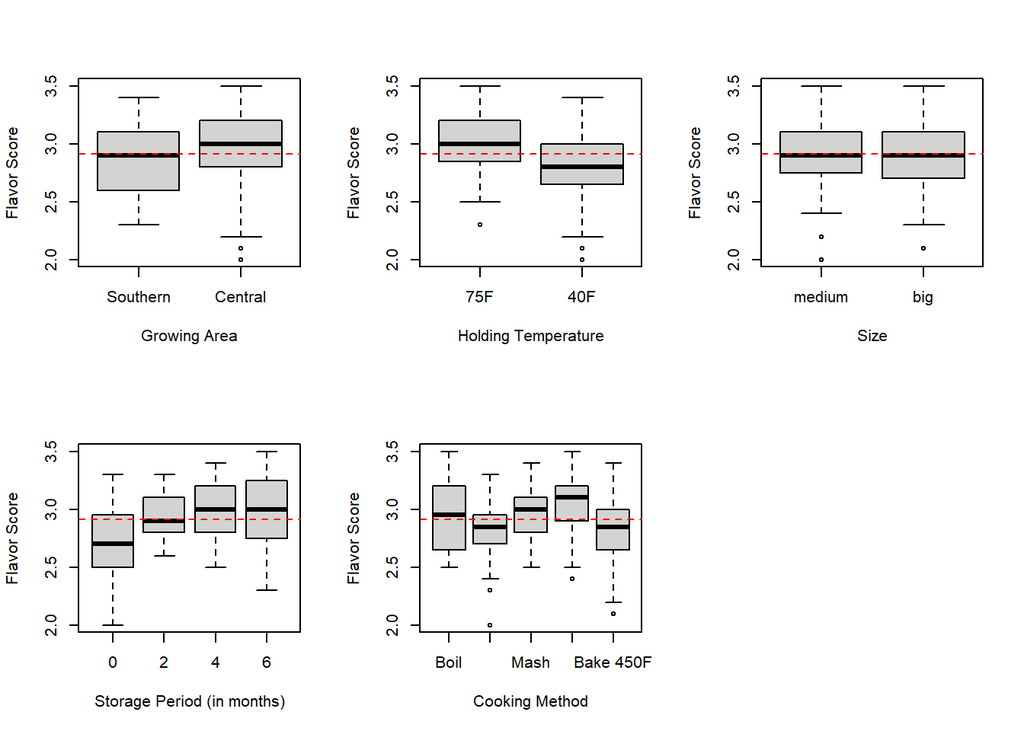

```r
#Some boxplots (we only have discrete variables except the Flavor Score)

layout(matrix(1:6, nrow = 2, byrow = TRUE)) #permet d'afficher les prochains plots dans un "tableau" 1 row, 2 columns)

boxplot(Flavor ~ Growing_Area, data = potato_data, names = c("Southern", "Central"), ylab = "Flavor Score", xlab = "Growing Area")
abline(h = overall_mean_flavor, col = "red", lty = 2)

boxplot(Flavor ~ Temperature, data = potato_data, names = c("75F", "40F"), ylab = "Flavor Score", xlab = "Holding Temperature")
abline(h = overall_mean_flavor, col = "red", lty = 2)

boxplot(Flavor ~ Size, data = potato_data, names = c("medium", "big"), ylab = "Flavor Score", xlab = "Size")
abline(h = overall_mean_flavor, col = "red", lty = 2)

boxplot(Flavor ~ Storage_period, data = potato_data, names = c("0", "2", "4", "6"), ylab = "Flavor Score", xlab = "Storage Period (in months)")
abline(h = overall_mean_flavor, col = "red", lty = 2)

boxplot(Flavor ~ Cooking_Method, data = potato_data, names = c("Boil", "Steam", "Mash", "Bake 350F", "Bake 450F"), ylab = "Flavor Score", xlab = "Cooking Method")
abline(h = overall_mean_flavor, col = "red", lty = 2)
```

Seems that the size of the potato does not affect the Flavor score (mean doesn’t change much). We suspect that there is interaction between the Storage Period and the cooking method, so we might want to include it into our regression Model.

#### *Fitting an ANOVA model*

In this case, the regression model has the formula:

```r
flavor.aov <- aov(Flavor ~ Storage_period*Cooking_Method, data=potato_data)
#weightgain = intercept + b1 * Storage_period + b2 * Cooking_Method + b3*Storage_period*Cooking_Method

summary(flavor.aov)
```

```
##                                Df Sum Sq Mean Sq F value   Pr(>F)
## Storage_period                  1  1.514  1.5138  21.117 8.86e-06 ***
## Cooking_Method                  1  0.003  0.0031   0.044    0.835
## Storage_period:Cooking_Method   1  0.020  0.0196   0.273    0.602
## Residuals                     156 11.183  0.0717
## ---
## Signif. codes:  0 '***' 0.001 '**' 0.01 '*' 0.05 '.' 0.1 ' ' 1
```

```r
coef(flavor.aov)
```

```
##                   (Intercept)                Storage_period
##                      2.650625                      0.108000
##                Cooking_Method Storage_period:Cooking_Method
##                      0.014375                     -0.007000
```

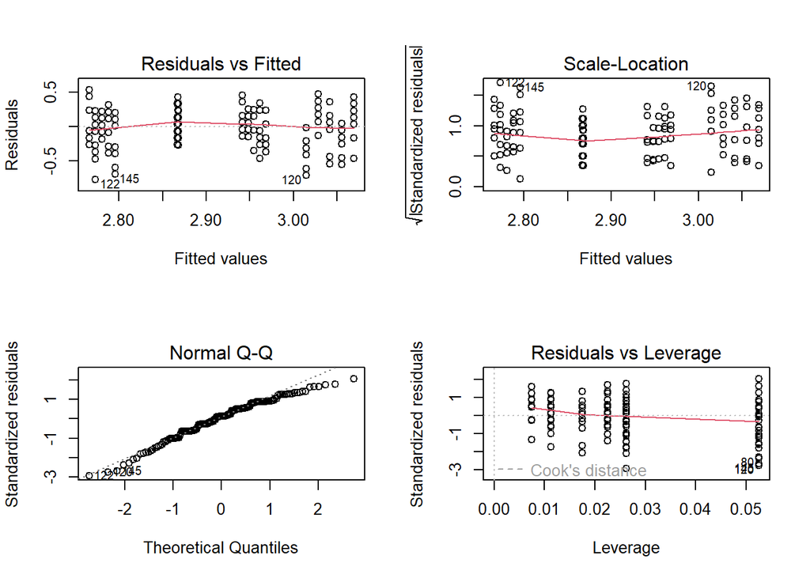

```r
layout(matrix(1:4,ncol=2))
plot(flavor.aov)
```